# Reproducible Research: Peer Assessment 1

## Loading and preprocessing the data

```r
activity_data <- read.csv(unz("activity.zip", "activity.csv"))
#Removing missing values
na_values <- is.na(activity_data$steps)
activity_data <- activity_data[!na_values,]
activity_data$date <- as.Date(activity_data$date)
```

## What is mean total number of steps taken per day?

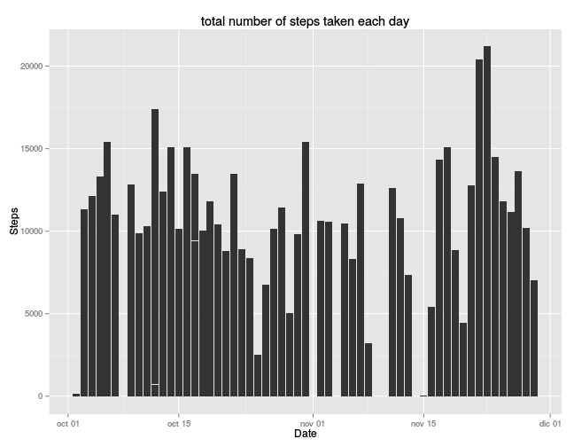

```r
library(ggplot2)
histogram <- ggplot(activity_data, aes(x=date, y=steps))
histogram <- histogram + geom_histogram(stat="identity") +
             ylab("Steps") + xlab("Date") + ggtitle("total number of steps taken each day")
print(histogram)
```

The mean and median can be calculated in R; in order to do so, first we take the numbers of steps for each day.

```r
steps_each_day <- c()
for(day in unique(as.factor(activity_data$date))){
    stepsday <- sum(activity_data[activity_data$date == day,1])
    steps_each_day <- c(steps_each_day, stepsday)
}
```

Then we calculate the mean

```r
mean(steps_each_day)
```

```
## [1] 10766
```

Finally we calculate the median

```r
median(steps_each_day)
```

```
## [1] 10765
```

[output not shown]

[figure not shown]

The interval with the maximum number of steps on average

```r
df[which.max(df[,1]),2]
```

```
## [1] 835
```

## Imputing missing values

To calculate the total number of missing values

```r
sum(as.numeric(na_values))
```

```
## [1] 2304
```

```r
new_data <- read.csv(unz("activity.zip", "activity.csv"))
for(value in 1:length(new_data[,1])){
    if(is.na(new_data[value,1])){
        inter <- new_data[value,3]
        index <- match(inter, intervals)
        new_data[value,1] <- steps_interval[index]
    }
}
```

[figure not shown]

```r
histogram2 <- ggplot(new_data, aes(x=date, y=steps))
histogram2 <- histogram + geom_histogram(stat="identity") +
             ylab("Steps") + xlab("Date") + ggtitle("histogram of the total number of steps taken each day after missing values were imputed")
print(histogram2)
```

```r
new_data$date <- as.Date(new_data$date)
print(class(new_data$date))
```

```
## [1] "Date"
```

```r
steps_each_day2 <- c()
for(day in unique(as.factor(new_data$date))){
    stepsday <- sum(new_data[new_data$date == day,1])
    steps_each_day2 <- c(steps_each_day2, stepsday)
}
```

We calculate the mean

```r
mean(steps_each_day2)
```

```
## [1] 10766
```

Finally we calculate the median

```r
median(steps_each_day2)
```

```
## [1] 10766
```

With this new data the mean is the same as the median. The median compared to the median of the data without missing values is almost the same. We can say that there's no significant impact in not taken into account missing values or replacing them.

## Are there differences in activity patterns between weekdays and weekends?

```r
days <- c("weekend", "weekday", "weekday", "weekday", "weekday", "weekday", "weekend")[as.POSIXlt(new_data$date)$wday + 1]
new_data$week <- as.factor(days)
```

Now graph steps in weekdays in contrast to steps in weekend days

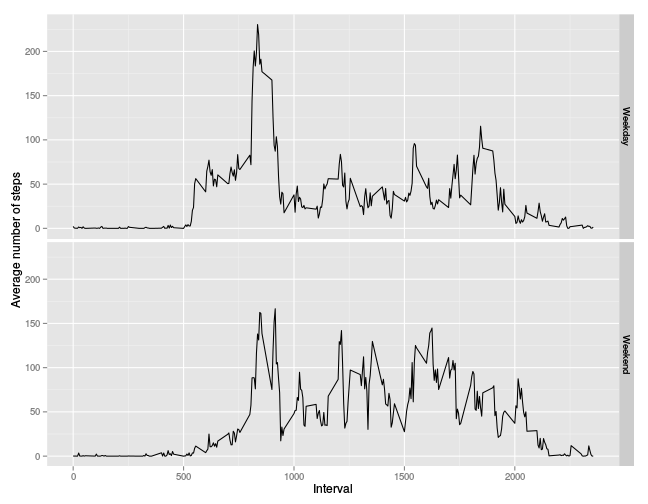

```r
intervals <- unique(activity_data$interval)
steps_weekdays <- c()
steps_weekend <- c()
for(inter in intervals){
    step_weekdays <- mean(new_data[new_data$interval == inter & new_data$week == "weekday",1])
    step_weekend <- mean(new_data[new_data$interval == inter & new_data$week == "weekend",1])
    steps_weekdays <- c(steps_weekdays, step_weekdays)
    steps_weekend <- c(steps_weekend, step_weekend)
}
week <- c(rep("Weekday", length(intervals)), rep("Weekend", length(intervals)))
intervals <- c(intervals, intervals)
average <- c(steps_weekdays, steps_weekend)
df <- data.frame(Average=average, inter=intervals, Week=week)
graph2 <- ggplot(df, aes(x=inter, y=Average))
graph2 <- graph2 + geom_line() + facet_grid(Week ~ .) +
          xlab("Interval") + ylab("Average number of steps")
print(graph2)
```